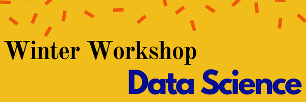

*Without data you are just another person with an opinion*  
- W. Edwards Deming

#### About the workshop

Winter workshop in data science is a two-day intensive data science program, held on weekends, in Chennai and Bangalore, where a team of data enthusiasts gets training in fundamentals of data science. The workshop is designed to demystify data science and to empower people perform data analytics using the R programming language. We will study and practice a wide range of topics, including R fundamentals, R markdown, visualization and data manipulation.

#### Expectations

The workshop **does not** have any prerequisites, although a little programming experince will be a huge plus. There will be both hands-on sessions and lectures, and the trainees are encouraged (but not required) to bring their own data sets. Towards the end of this workshop the student will exhibit in-depth understanding of data science and analysis methods as well as proficiency in R. He/She will will be encourged to pursue and produce a portfolio that demonstrates mastery of analysis and visualization methods.

#### Agenda

Each day, the session will begin at 9 am and end at 7 pm with on-your-own lunch break between 12 noon and 1.00 pm. Lectures will be held between 9-10 am, 1-2 pm, 4-5 pm, each followed by hands-on sessions for two hours. The lecture agenda are as follows:

Saturday: R fundamentals, R Markdown, Visualization

Sunday: Data transformation, Explortory data analysis and Wrangle

#### Where to apply and fees

Fill out an application here by November 15, 2017 at 11:59 pm. Due to volume restrictions, late applications will not be considered. Applicants will be notified at the end November with instructions to pay the fees. If you miss the deadline, you can sign up for the general workshop form to be notified of future opportunities. The fee for the workshop is Rs. 5500/- per day or Rs. 10,000 for the entire two-day workshop.

#### About the organizers

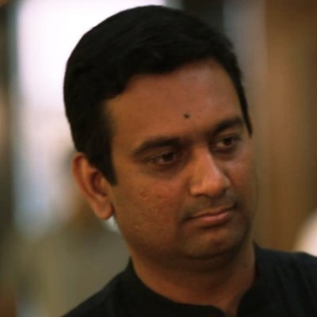

Dr. Kasthuri Kannan, PhD, is an Assistant Professor of Pathology at New York University (NYU). He has more than 10 years of experience in data science and analytics. He started his data science career in 2006 in a company where he contributed to data mining projects and obtained directed insights in aircraft movement operations at the Tinker Air Force base. He proposed efficient strategies for aircraft logistics through analysis of aircraft movement data using machine learning algorithms. He is trained in mathematics and computer science with postdoctoral training at Memorial Sloan-Kettering Cancer Center (one of the top cancer research institutes in the world), where his data science skills were extensively applied to genomics resulting in top-notch publications. He is actively advising and collaborating with several scientists and physician-scientists, translating data science findings to clinical care, and is passionate about teaching and science communication. Currently, he is directing and teaching a course in data science and biomedical informatics at NYU, a required course for masters students in biomedical informatics. The course content can be viewed at: https://kannan-kasthuri.github.io/pda.html and Dr. Kannan’s webpage can be accessed here: https://kannan-kasthuri.github.io

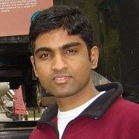

Dr. Anand Lakshmanan is the founder and CEO of SIRPI PRODUCTS AND SERVICES PVT LTD (http://sirpi.co.in) He believes all scientists and professionals need to be data-savvy to make decisions and persuade actions. He has 17+ years experience across academia and industry. Most recently he worked at Apple in California for about 6 years.

Twitter: https://twitter.com/lan24hd

LinkedIn: https://www.linkedin.com/in/alakshmanan